# HW2 Time Series Regression for Predicting Mortgaged House Sales

Emirhan Esen

05 05 2021

# Introduction

The aim of this homework is to understand and forecast the Mortgaged House Sales Statistics in Turkey at a monthly level. What is Mortgaged House Sales and House Loan? By paying installments, housing loans can be taken by applying to banks to become a homeowner in the long term. The bank that gives the home loan mortgages the real estate until the loan debt is fully paid. In cases where the debt of the house is not paid, the bank has the right to sell the real estate. Are mortgaged house sales statistics related to housing interest rates for bank loans and/or Consumer Tendency survey of the probability of buying or building a home? I try to build a time series regression model for forecasting next month’s value of the mortgaged house sales. I downloaded the related data from CBRT’s Electronic Data Delivery System and they are collected at a monthly frequency from 01/2013 to 03/2021.

# Data Manipulation and Visualization

I downloaded the following time series and survey from CBRT’s Electronic Data Delivery System: 1- House Sales Statistics - Turkey - - Mortgaged sales(TURKSTAT) - Level 2- Housing (TRY)(Flow Data, %) - Level 3- The probability of buying or building a home (over the next 12 months) - Level All of them are collected at a monthly frequency from 01/2013 to 03/2021. I put them in a single .csv file which has four columns.

```r
require(data.table)
require(lubridate)
require(ggplot2)
require(forecast)
require(GGally)

#data reading
salesdata=fread("alldata.csv")
str(salesdata)
```

```
## Classes 'data.table' and 'data.frame':   100 obs. of  4 variables:
##  $ Tarih: chr  "2013-01" "2013-02" "2013-03" "2013-04" ...
##  $ sales: num  36581 37150 41809 40812 45270 ...
##  $ kredi: num  9.78 9.58 9.31 9.06 8.77 ...
##  $ niyet: num  10.7 10.5 11.3 10.6 10.2 ...
##  - attr(*, ".internal.selfref")=<externalptr>
```

I converted the “Tarih” column to “date” column as a date class by using lubridate package. Then I deleted the “Tarih” column which class is character.

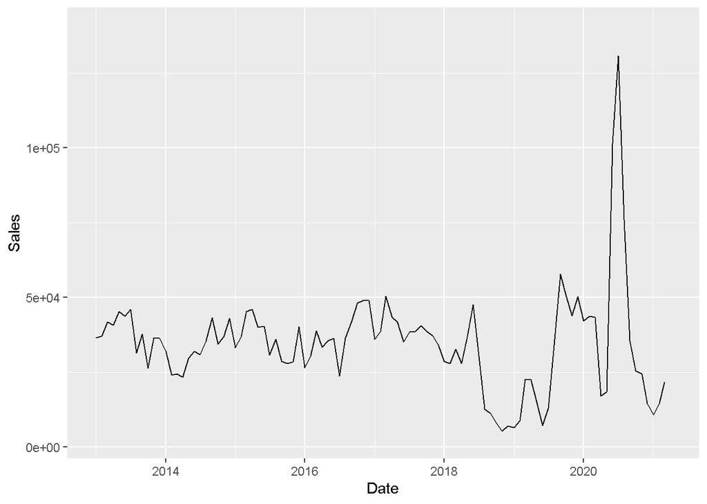

```r
salesdata[,date := ym(Tarih) ]
salesdata[,Tarih := NULL]

ggplot(salesdata) + aes(x=date , y=sales) + geom_line() + ylim(3000,140000) + xlab('Date') +
  ylab('Sales')
```

Firstly I checked the correlation between sales and other variables. There is a high correlation with bank loans. So, I started with it. Then, I add the survey data and trend to linear model. In every step, I observed F-statistics, R-squared values, Breusch-Godfrey test and residual’s mean and variance. Then I made predictions with the related model and plot them. Also, I checked if the salesdata has any correlation with months and intercept point. I did not add them to the final linear model because they don’t have a strong correlation.

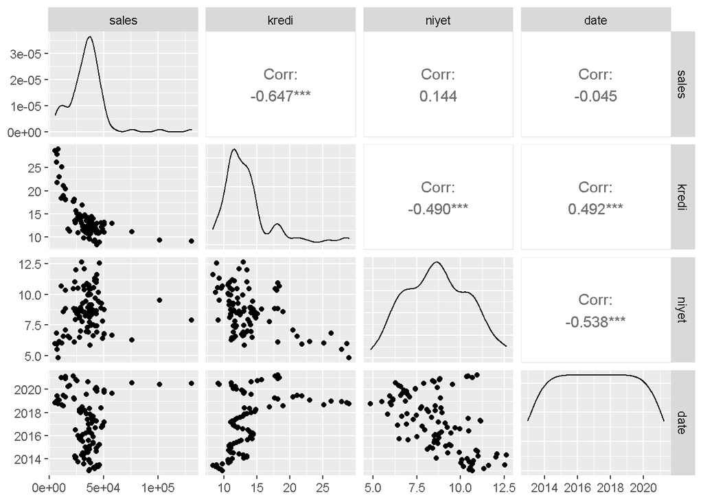

```r
# multi-graph, correlation
ggpairs(salesdata)
```

```r
# adding "kredi" variable to the model
ts_reg=lm(sales~kredi,salesdata)
summary(ts_reg)
```

```
##
## Call:
## lm(formula = sales ~ kredi, data = salesdata)
##
## Residuals:
##    Min     1Q Median     3Q    Max
## -22946  -6399  -1755   2776  83874
##
## Coefficients:
##             Estimate Std. Error t value Pr(>|t|)
## (Intercept)  70624.7     4494.3  15.714  < 2e-16 ***
## kredi        -2610.1      312.2  -8.361 4.56e-13 ***
## ---
## Signif. codes:  0 '***' 0.001 '**' 0.01 '*' 0.05 '.' 0.1 ' ' 1
##
## Residual standard error: 13170 on 97 degrees of freedom
##   (1 observation deleted due to missingness)
## Multiple R-squared:  0.4188, Adjusted R-squared:  0.4128
## F-statistic: 69.91 on 1 and 97 DF,  p-value: 4.559e-13
```

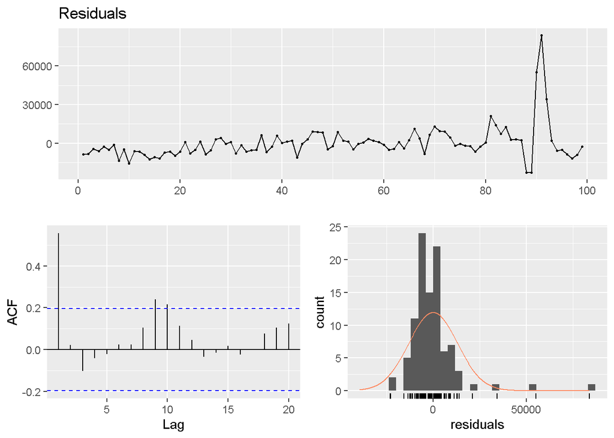

```
##
##  Breusch-Godfrey test for serial correlation of order up to 12
##
## data:  Residuals
## LM test = 55.381, df = 12, p-value = 1.547e-07
```

```r
checkresiduals(ts_reg , lag= 12)
```

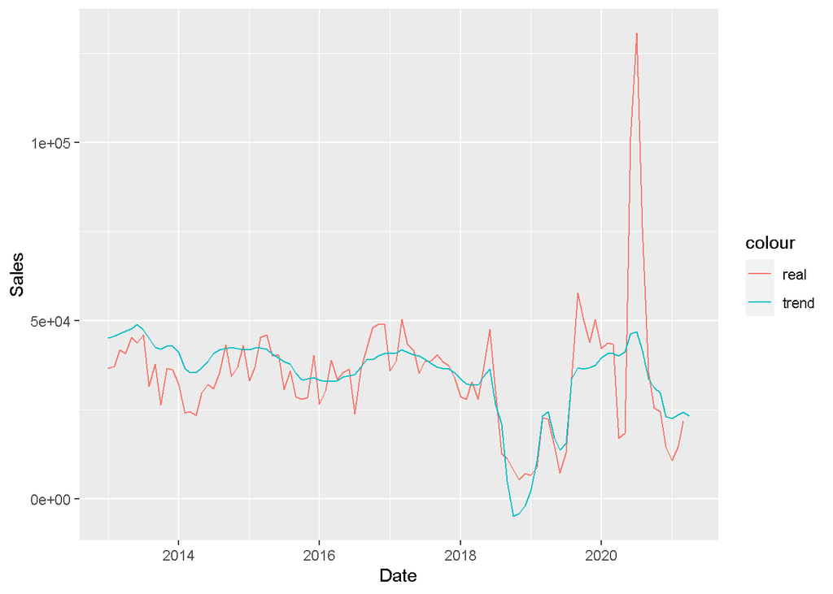

```r
salesdata[,p_kredi:=predict(ts_reg,salesdata)]

ggplot(salesdata, aes(x=date)) +
  geom_line(aes(y=sales,color='real')) +
  geom_line(aes(y=p_kredi, color='trend'))+
  xlab('Date') +
  ylab('Sales')
```

```r
# adding "niyet" variable to the model
ts_reg=lm(sales~kredi+niyet,salesdata)
summary(ts_reg)
```

```
##
## Call:
## lm(formula = sales ~ kredi + niyet, data = salesdata)
##
## Residuals:
##    Min     1Q Median     3Q    Max
## -29608  -5627  -1569   3430  79550
##
## Coefficients:
##             Estimate Std. Error t value Pr(>|t|)
## (Intercept)  99318.9    10755.4   9.234 6.57e-15 ***
## kredi        -3130.8      349.8  -8.949 2.69e-14 ***
## niyet        -2487.5      853.5  -2.915  0.00443 **
## ---
## Signif. codes:  0 '***' 0.001 '**' 0.01 '*' 0.05 '.' 0.1 ' ' 1
##
## Residual standard error: 12690 on 96 degrees of freedom
##   (1 observation deleted due to missingness)
## Multiple R-squared:  0.4661, Adjusted R-squared:  0.455
## F-statistic:  41.9 on 2 and 96 DF,  p-value: 8.294e-14
```

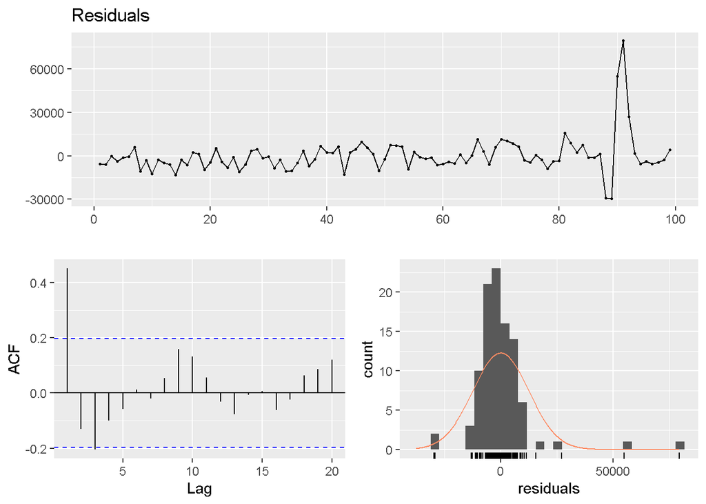

```
##
##  Breusch-Godfrey test for serial correlation of order up to 12
##
## data:  Residuals
## LM test = 45.492, df = 12, p-value = 8.485e-06
```

```r
checkresiduals(ts_reg , lag= 12)
```

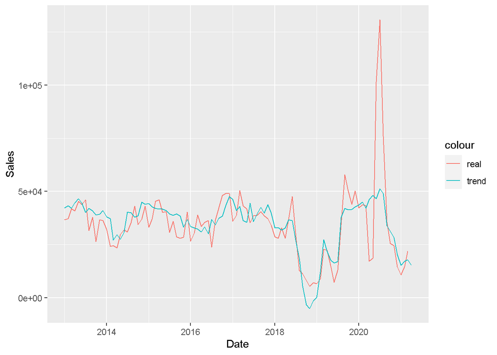

```r
salesdata[,p_kredi_niyet:=predict(ts_reg,salesdata)]

ggplot(salesdata, aes(x=date)) +
  geom_line(aes(y=sales,color='real')) +
  geom_line(aes(y=p_kredi_niyet, color='trend'))+
  xlab('Date') +
  ylab('Sales')
```

```r
# adding "trend" variable to the model
salesdata[,trend := 1:.N]
head(salesdata)
```

```
##    sales kredi niyet       date  p_kredi p_kredi_niyet trend
## 1: 36581  9.78 10.67 2013-01-01 45097.89      42158.36     1
## 2: 37150  9.58 10.49 2013-02-01 45619.91      43232.26     2
## 3: 41809  9.31 11.33 2013-03-01 46324.63      41988.11     3
## 4: 40812  9.06 10.56 2013-04-01 46977.16      44686.16     4
## 5: 45270  8.77 10.18 2013-05-01 47734.09      46539.33     5
## 6: 43763  8.30 11.62 2013-06-01 48960.84      44428.86     6
```

```r
tail(salesdata)
```

```
##    sales kredi niyet       date  p_kredi p_kredi_niyet trend
## 1: 24450 15.68  8.81 2020-11-01 29698.30      28313.27    95
## 2: 14631 18.19  8.84 2020-12-01 23146.95      20380.31    96
## 3: 10732 18.39 10.67 2021-01-01 22624.93      15202.09    97
## 4: 14669 17.99 10.35 2021-02-01 23668.97      17250.40    98
## 5: 21815 17.74 10.45 2021-03-01 24321.49      17784.36    99
## 6:    NA 18.15 10.95 2021-04-01 23251.35      15256.99   100
```

```r
ts_reg=lm(sales~kredi+niyet+trend,salesdata)
summary(ts_reg)
```

```
##
## Call:
## lm(formula = sales ~ kredi + niyet + trend, data = salesdata)
##
## Residuals:
##    Min     1Q Median     3Q    Max
## -34494  -5653  -1200   3374  71795
##
## Coefficients:
##             Estimate Std. Error t value Pr(>|t|)
## (Intercept) 83429.64   11309.96   7.377 6.05e-11 ***
## kredi       -3440.35     345.93  -9.945  < 2e-16 ***
## niyet       -1189.51     902.30  -1.318  0.19057
## trend         178.27      53.91   3.307  0.00133 **
## ---
## Signif. codes:  0 '***' 0.001 '**' 0.01 '*' 0.05 '.' 0.1 ' ' 1
##
## Residual standard error: 12080 on 95 degrees of freedom
##   (1 observation deleted due to missingness)
## Multiple R-squared:  0.5212, Adjusted R-squared:  0.5061
## F-statistic: 34.47 on 3 and 95 DF,  p-value: 3.665e-15
```

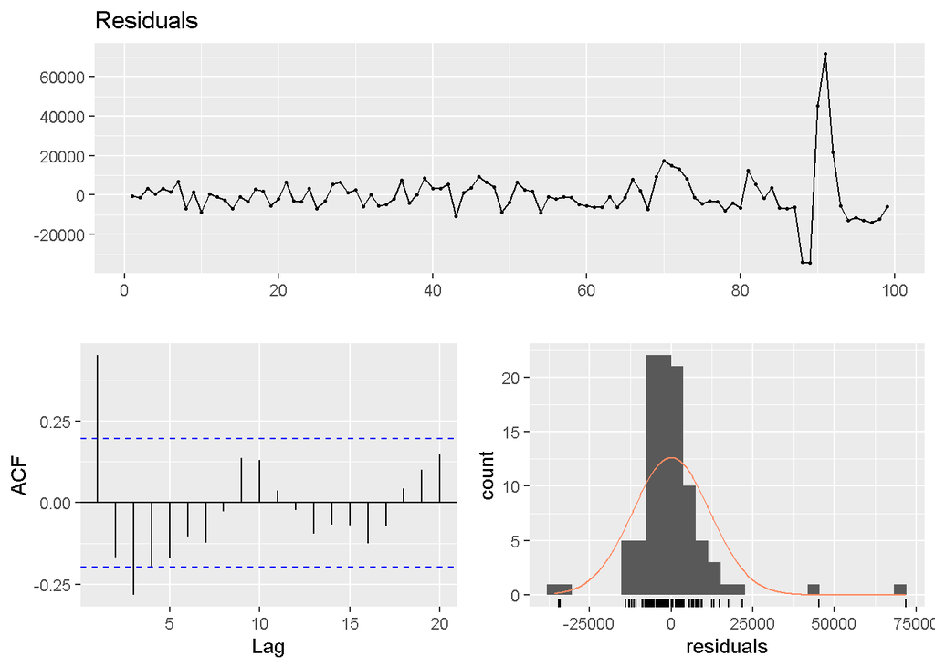

```
##
##  Breusch-Godfrey test for serial correlation of order up to 12
##
## data:  Residuals
## LM test = 52.092, df = 12, p-value = 5.972e-07
```

```r
checkresiduals(ts_reg , lag= 12)
```

```r
salesdata[,p_kredi_niyet_trend:=predict(ts_reg,salesdata)]

ggplot(salesdata, aes(x=date)) +
  geom_line(aes(y=sales,color='real')) +
  geom_line(aes(y=p_kredi_niyet_trend, color='trend'))+
  xlab('Date') +
  ylab('Sales')
```

[output not shown]

```r
#adding month information as a variable
salesdata[,month := as.character(lubridate::month(date, label = T))]
ts_reg2=lm(sales~kredi+niyet+trend+month,salesdata)
summary(ts_reg2)
```

```
##
## Call:
## lm(formula = sales ~ kredi + niyet + trend + month, data = salesdata)
##
## Residuals:
##    Min     1Q Median     3Q    Max
## -30689  -4598  -1099   4628  65474
##
## Coefficients:
##             Estimate Std. Error t value Pr(>|t|)
## (Intercept) 81831.91   12424.69   6.586 3.71e-09 ***
## kredi       -3385.97     351.66  -9.629 3.23e-15 ***
## niyet       -1084.24     968.64  -1.119  0.26619
## trend         175.72      55.26   3.180  0.00206 **
## monthAra     1713.65    6177.75   0.277  0.78216
## monthEki      295.33    6138.12   0.048  0.96174
## monthEyl     2818.99    6120.10   0.461  0.64627
## monthHaz     6115.07    6125.70   0.998  0.32102
## monthKas      -32.32    6146.40  -0.005  0.99582
## monthMar      679.41    5979.21   0.114  0.90980
## monthMay    -3270.77    6114.50  -0.535  0.59412
## monthNis    -4158.89    6133.60  -0.678  0.49960
## monthOca    -4586.50    5952.49  -0.771  0.44315
## monthŞub    -4529.51    5942.96  -0.762  0.44810
## monthTem     6825.33    6106.38   1.118  0.26687
## ---
## Signif. codes:  0 '***' 0.001 '**' 0.01 '*' 0.05 '.' 0.1 ' ' 1
##
## Residual standard error: 12200 on 84 degrees of freedom
##   (1 observation deleted due to missingness)
## Multiple R-squared:  0.5681, Adjusted R-squared:  0.4961
## F-statistic: 7.891 on 14 and 84 DF,  p-value: 2.243e-10
```

```r
salesdata[, trend_constant_monthly_sales := predict(ts_reg2,salesdata)]
ggplot(salesdata, aes(x=date)) +
  geom_line(aes(y=sales,color='real')) +
  geom_line(aes(y=p_kredi_niyet_trend, color='trend'))+
  xlab('Date') +
  ylab('Sales')
```

[output not shown]

```r
#without intercept
ts_reg3=lm(sales~-1+kredi+niyet+trend,salesdata)
summary(ts_reg3)
```

```
##
## Call:
## lm(formula = sales ~ -1 + kredi + niyet + trend, data = salesdata)
##
## Residuals:
##    Min     1Q Median     3Q    Max
## -40355  -5967   1607   7856  77462
##
## Coefficients:
##       Estimate Std. Error t value Pr(>|t|)
## kredi -1958.42     351.33  -5.574 2.28e-07 ***
## niyet  5006.87     411.02  12.182  < 2e-16 ***
## trend   347.21      60.88   5.703 1.30e-07 ***
## ---
## Signif. codes:  0 '***' 0.001 '**' 0.01 '*' 0.05 '.' 0.1 ' ' 1
##
## Residual standard error: 15070 on 96 degrees of freedom
##   (1 observation deleted due to missingness)
## Multiple R-squared:  0.8529, Adjusted R-squared:  0.8483
## F-statistic: 185.6 on 3 and 96 DF,  p-value: < 2.2e-16
```